# 🧠 Investment Strategy Evaluation

**Author:** Cedric Tuttle  
**Date:** November 2025  
**Tools:** Python, Pandas, NumPy, Scikit-learn, Matplotlib, SciPy

### 📈 Project Overview

To demonstrate data science and analytical skills, I’ll:

- Use **Python** for data collection and cleaning
- Apply **machine learning** models to predict returns
- Conduct **A/B testing** to compare strategy performance
- Visualize and interpret results clearly

### 🧩 Key Questions

1. Which investment strategy yields the highest returns and lowest volatility?
2. Are the differences in returns statistically significant?
3. Can machine learning improve or optimize these strategies?

## 📊 Data Collection and Exploration

I’ll start by importing core Python libraries and previewing the structure of the data.

```python
# Import libraries
import pandas as pd
import numpy as np
import matplotlib.pyplot as plt
import seaborn as sns

# Set display options
pd.set_option('display.max_columns', None)
sns.set(style='whitegrid')

# Load Datasets
index = pd.read_csv("sp500_index.csv")
companies = pd.read_csv("sp500_companies.csv")

# Preview each
print("\nIndex Data:")
display(index.head())

print("\nCompanies Data:")
display(companies.head())
```

```
Index Data:
```

|  | Date | S&P500 |
| --- | --- | --- |
| 0 | 2014-12-22 | 2078.54 |
| 1 | 2014-12-23 | 2082.17 |
| 2 | 2014-12-24 | 2081.88 |
| 3 | 2014-12-26 | 2088.77 |
| 4 | 2014-12-29 | 2090.57 |

```
Companies Data:
```

|  | Exchange | Symbol | Shortname | Longname | Sector | Industry | Currentprice | Marketcap | Ebitda | Revenuegrowth | City | State | Country | Fulltimeemployees | Longbusinesssummary | Weight |
| --- | --- | --- | --- | --- | --- | --- | --- | --- | --- | --- | --- | --- | --- | --- | --- | --- |
| 0 | NMS | AAPL | Apple Inc. | Apple Inc. | Technology | Consumer Electronics | 254.49 | 3846819807232 | 1.346610e+11 | 0.061 | Cupertino | CA | United States | 164000.0 | Apple Inc. designs, manufactures, and markets ... | 0.069209 |
| 1 | NMS | NVDA | NVIDIA Corporation | NVIDIA Corporation | Technology | Semiconductors | 134.70 | 3298803056640 | 6.118400e+10 | 1.224 | Santa Clara | CA | United States | 29600.0 | NVIDIA Corporation provides graphics and compu... | 0.059350 |
| 2 | NMS | MSFT | Microsoft Corporation | Microsoft Corporation | Technology | Software - Infrastructure | 436.60 | 3246068596736 | 1.365520e+11 | 0.160 | Redmond | WA | United States | 228000.0 | Microsoft Corporation develops and supports so... | 0.058401 |
| 3 | NMS | AMZN | Amazon.com, Inc. | Amazon.com, Inc. | Consumer Cyclical | Internet Retail | 224.92 | 2365033807872 | 1.115830e+11 | 0.110 | Seattle | WA | United States | 1551000.0 | Amazon.com, Inc. engages in the retail sale of... | 0.042550 |
| 4 | NMS | GOOGL | Alphabet Inc. | Alphabet Inc. | Communication Services | Internet Content & Information | 191.41 | 2351625142272 | 1.234700e+11 | 0.151 | Mountain View | CA | United States | 181269.0 | Alphabet Inc. offers various products and plat... | 0.042309 |

```python
import yfinance as yf
import pandas as pd
import matplotlib.pyplot as plt
import seaborn as sns

sns.set(style='whitegrid')
pd.set_option('display.max_columns', None)

# Example: Fetch Apple and Microsoft daily prices for the last 5 years
symbols = ['AAPL', 'MSFT', 'JNJ', 'JPM', 'XOM', 'KO', 'DIS', 'CVX']  # You can expand this list to more S&P 500 tickers
stocks = yf.download(symbols, start="2018-01-01", end="2023-12-31")

# yf.download returns a multi-index DataFrame for multiple tickers
# You can flatten it if needed:
stocks = stocks.stack(level=1).rename_axis(['Date', 'Ticker']).reset_index()

print("Stocks Data:")
display(stocks.head())

# Fetch S&P 500 index data (ticker: ^GSPC)
sp500_index = yf.download('^GSPC', start="2018-01-01", end="2023-12-31")
sp500_index.reset_index(inplace=True)

print("\nS&P 500 Index Data:")
display(sp500_index.head())
```

```
Stocks Data:
```

| Price | Date | Ticker | Close | High | Low | Open | Volume |
| --- | --- | --- | --- | --- | --- | --- | --- |
| 0 | 2018-01-02 | AAPL | 40.380985 | 40.390364 | 39.677729 | 39.888708 | 102223600 |
| 1 | 2018-01-02 | CVX | 91.336227 | 91.450771 | 89.875764 | 89.997467 | 5626000 |
| 2 | 2018-01-02 | DIS | 106.943237 | 106.952798 | 103.843983 | 104.217040 | 11014300 |
| 3 | 2018-01-02 | JNJ | 112.059998 | 112.639494 | 111.649526 | 112.406092 | 6842100 |
| 4 | 2018-01-02 | JPM | 86.730347 | 86.786587 | 85.814436 | 86.473249 | 13578800 |

```
S&P 500 Index Data:
```

| Price Ticker | Date | Close ^GSPC | High ^GSPC | Low ^GSPC | Open ^GSPC | Volume ^GSPC |
| --- | --- | --- | --- | --- | --- | --- |
| 0 | 2018-01-02 | 2695.810059 | 2695.889893 | 2682.360107 | 2683.729980 | 3397430000 |
| 1 | 2018-01-03 | 2713.060059 | 2714.370117 | 2697.770020 | 2697.850098 | 3544030000 |
| 2 | 2018-01-04 | 2723.989990 | 2729.290039 | 2719.070068 | 2719.310059 | 3697340000 |
| 3 | 2018-01-05 | 2743.149902 | 2743.449951 | 2727.919922 | 2731.330078 | 3239280000 |
| 4 | 2018-01-08 | 2747.709961 | 2748.510010 | 2737.600098 | 2742.669922 | 3246160000 |

## Step 1: Data Cleaning & Preparation

Before we can evaluate and compare investment strategies, we need to ensure our data is clean, consistent, and ready for analysis. In this step, we:

1. **Convert date columns to datetime**  
   This allows us to correctly sort and align time series data.
2. **Sort the data by ticker and date**  
   Ensures that calculations like daily returns and rolling metrics are accurate.
3. **Compute daily returns**  
   Returns are the fundamental metric for evaluating investment strategies.
4. **Compute optional rolling metrics**  
   Moving averages and rolling volatility will be useful for momentum and mean reversion strategies.
5. **Handle missing values**  
   Dropping initial NaNs ensures calculations are correct and prevents errors in later steps.
6. **Sanity checks and visualization**  
   We inspect the data to confirm correctness and plot sample stock prices to visually verify trends.

```python
# Convert Date columns to datetime
stocks['Date'] = pd.to_datetime(stocks['Date'])
sp500_index['Date'] = pd.to_datetime(sp500_index['Date'])
```

```python
# Sort data by Ticker and Date
stocks = stocks.sort_values(by=['Ticker', 'Date']).reset_index(drop=True)
sp500_index = sp500_index.sort_values(by='Date').reset_index(drop=True)
```

```python
# Compute daily returns
stocks['Return'] = stocks.groupby('Ticker')['Close'].pct_change()
sp500_index['Return'] = sp500_index['Close'].pct_change()
```

```python
# Optional: compute rolling metrics for strategies (momentum / mean reversion)
# 20-day moving average
stocks['MA20'] = stocks.groupby('Ticker')['Close'].transform(lambda x: x.rolling(20).mean())
# 20-day rolling volatility
stocks['Vol20'] = stocks.groupby('Ticker')['Return'].transform(lambda x: x.rolling(20).std())
```

```python
# Handle missing values (first few rows per ticker will be NaN after returns/rolling metrics)
stocks = stocks.dropna().reset_index(drop=True)
```

```
<class 'pandas.core.frame.DataFrame'>
RangeIndex: 11912 entries, 0 to 11911
Data columns (total 10 columns):
 #   Column  Non-Null Count  Dtype
---  ------  --------------  -----
 0   Date    11912 non-null  datetime64[ns]
 1   Ticker  11912 non-null  object
 2   Close   11912 non-null  float64
 3   High    11912 non-null  float64
 4   Low     11912 non-null  float64
 5   Open    11912 non-null  float64
 6   Volume  11912 non-null  int64
 7   Return  11912 non-null  float64
 8   MA20    11912 non-null  float64
 9   Vol20   11912 non-null  float64
dtypes: datetime64[ns](1), float64(7), int64(1), object(1)
memory usage: 930.8+ KB
None
<class 'pandas.core.frame.DataFrame'>
RangeIndex: 1509 entries, 0 to 1508
Data columns (total 7 columns):
 #   Column  Non-Null Count  Dtype
---  ------  --------------  -----
 0   Date    1509 non-null   datetime64[ns]
 1   Close   1509 non-null   float64
 2   High    1509 non-null   float64
 3   Low     1509 non-null   float64
 4   Open    1509 non-null   float64
 5   Volume  1509 non-null   int64
 6   Return  1508 non-null   float64
dtypes: datetime64[ns](1), float64(5), int64(1)
memory usage: 82.7 KB
None
```

| Price | Date | Ticker | Close | High | Low | Open | Volume | Return | MA20 | Vol20 |
| --- | --- | --- | --- | --- | --- | --- | --- | --- | --- | --- |
| 0 | 2018-01-31 | AAPL | 39.248760 | 39.485526 | 39.030752 | 39.117486 | 129915600 | 0.002755 | 40.810569 | 0.009462 |
| 1 | 2018-02-01 | AAPL | 39.330791 | 39.527702 | 39.091683 | 39.187796 | 188923200 | 0.002090 | 40.758410 | 0.009490 |
| 2 | 2018-02-02 | AAPL | 37.624233 | 39.101073 | 37.530467 | 38.913537 | 346375200 | -0.043390 | 40.611546 | 0.013249 |
| 3 | 2018-02-05 | AAPL | 36.684219 | 38.416575 | 36.569353 | 37.296053 | 290954000 | -0.024984 | 40.394592 | 0.013567 |
| 4 | 2018-02-06 | AAPL | 38.217312 | 38.379061 | 36.100510 | 36.295078 | 272975200 | 0.041792 | 40.261911 | 0.017207 |

|  | Date | Close | High | Low | Open | Volume | Return |
| --- | --- | --- | --- | --- | --- | --- | --- |
| 0 | 2018-01-02 | 2695.810059 | 2695.889893 | 2682.360107 | 2683.729980 | 3397430000 | NaN |
| 1 | 2018-01-03 | 2713.060059 | 2714.370117 | 2697.770020 | 2697.850098 | 3544030000 | 0.006399 |
| 2 | 2018-01-04 | 2723.989990 | 2729.290039 | 2719.070068 | 2719.310059 | 3697340000 | 0.004029 |
| 3 | 2018-01-05 | 2743.149902 | 2743.449951 | 2727.919922 | 2731.330078 | 3239280000 | 0.007034 |
| 4 | 2018-01-08 | 2747.709961 | 2748.510010 | 2737.600098 | 2742.669922 | 3246160000 | 0.001662 |

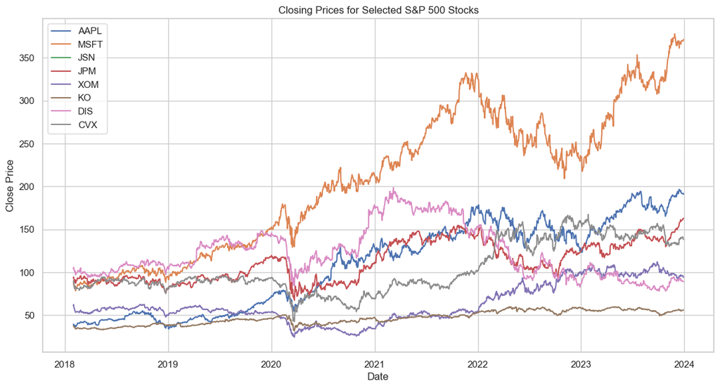

```python
# Quick sanity checks
print(stocks.info())
print(sp500_index.info())

display(stocks.head())
display(sp500_index.head())

# Example plot for multiple selected stocks
tickers = ['AAPL', 'MSFT', 'JSN', 'JPM', 'XOM', 'KO', 'DIS', 'CVX']

plt.figure(figsize=(14,7))

for ticker in tickers:
    subset = stocks[stocks['Ticker'] == ticker]
    sns.lineplot(data=subset, x='Date', y='Close', label=ticker)

plt.title("Closing Prices for Selected S&P 500 Stocks")
plt.xlabel("Date")
plt.ylabel("Close Price")
plt.legend()
plt.show()
```

```python
sp500_index.columns = [col[0] if isinstance(col, tuple) else col for col in sp500_index.columns]
sp500_index.rename(columns={'Close': 'Close', 'Return': 'Return'}, inplace=True)
```

## Step 2: Strategy Definition and Backtesting

In this step, we define and simulate investment strategies to evaluate their performance. Specifically, we:

1. **Define strategies:**
   - **Buy-and-Hold:** Buy a stock at the start and hold it until the end.
   - **Momentum:** Buy stocks that have performed well over a recent window (e.g., 20-day moving average).
2. **Backtest each strategy:**
   - Simulate daily returns based on the rules of each strategy.
   - Compute cumulative returns and other metrics (mean return, volatility, Sharpe ratio).
3. **Prepare for A/B testing:**
   - Collect daily returns from each strategy over the same period.
   - This allows statistical testing to determine if one strategy significantly outperforms another.
4. **Optional extension for ML:**
   - Use engineered features (moving averages, volatility, past returns) to predict future returns and generate signals.

```python
# Example: Buy-and-Hold daily returns
def buy_and_hold(df):
    df = df.copy()
    df['Signal'] = 1  # Always invested
    df['Strategy_Return'] = df['Return'] * df['Signal']
    df['Cumulative_Return'] = (1 + df['Strategy_Return']).cumprod()
    return df

# Selected tickers
tickers = ['AAPL', 'MSFT', 'JNJ', 'JPM', 'XOM', 'KO', 'DIS', 'CVX']

# Apply Buy-and-Hold to all tickers and store in a dictionary
bh_dict = {}
for ticker in tickers:
    bh_dict[ticker] = buy_and_hold(stocks[stocks['Ticker'] == ticker])
```

```python
# Example: Momentum strategy based on 20-day MA
def momentum_strategy(df):
    df = df.copy()
    # Buy when price is above MA20, otherwise cash (Signal = 0)
    df['Signal'] = (df['Close'] > df['MA20']).astype(int)
    df['Strategy_Return'] = df['Return'] * df['Signal']
    df['Cumulative_Return'] = (1 + df['Strategy_Return']).cumprod()
    return df

# Selected tickers
tickers = ['AAPL', 'MSFT', 'JNJ', 'JPM', 'XOM', 'KO', 'DIS', 'CVX']

# Apply Momentum strategy to all tickers and store in a dictionary
mom_dict = {}
for ticker in tickers:
    mom_dict[ticker] = momentum_strategy(stocks[stocks['Ticker'] == ticker])
```

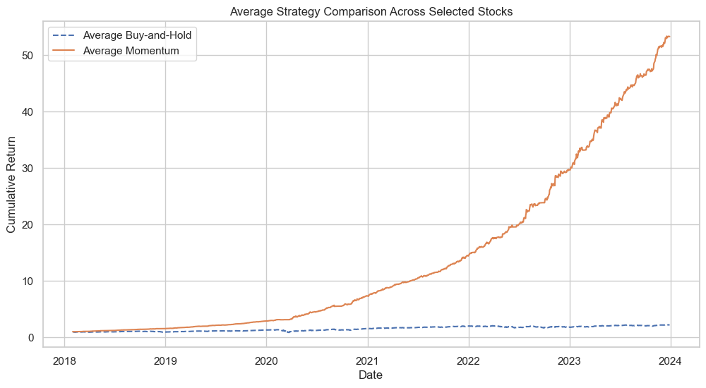

```python
# Initialize DataFrames to store cumulative returns
bh_cum_list = []
mom_cum_list = []

for ticker in tickers:
    bh_cum = bh_dict[ticker][['Date', 'Cumulative_Return']].copy()
    bh_cum = bh_cum.rename(columns={'Cumulative_Return': ticker})
    bh_cum_list.append(bh_cum.set_index('Date'))

    mom_cum = mom_dict[ticker][['Date', 'Cumulative_Return']].copy()
    mom_cum = mom_cum.rename(columns={'Cumulative_Return': ticker})
    mom_cum_list.append(mom_cum.set_index('Date'))

# Concatenate and compute row-wise mean
bh_avg = pd.concat(bh_cum_list, axis=1).mean(axis=1)
mom_avg = pd.concat(mom_cum_list, axis=1).mean(axis=1)

# Plot average cumulative returns
plt.figure(figsize=(12,6))
plt.plot(bh_avg.index, bh_avg.values, label='Average Buy-and-Hold', linestyle='--')
plt.plot(mom_avg.index, mom_avg.values, label='Average Momentum')
plt.title("Average Strategy Comparison Across Selected Stocks")
plt.xlabel("Date")
plt.ylabel("Cumulative Return")
plt.legend()
plt.show()
```

```python
# Extract average daily returns across all selected tickers
bh_returns = pd.concat([bh_dict[ticker]['Strategy_Return'] for ticker in tickers], axis=1).mean(axis=1)
mom_returns = pd.concat([mom_dict[ticker]['Strategy_Return'] for ticker in tickers], axis=1).mean(axis=1)

# These can now be used in a t-test or other statistical comparison
```

## Step 3: Strategy Comparison and A/B Testing

In this step, we statistically compare investment strategies to determine if differences in performance are significant. Specifically, we:

1. **Define the comparison metric:**
   - Daily returns of each strategy.
   - Optional: cumulative return, Sharpe ratio, volatility.
2. **Run an A/B test:**
   - Treat Buy-and-Hold as group A and Momentum as group B.
   - Use a t-test to see if the mean returns are significantly different.
3. **Visualize distributions and risk/return:**
   - Histograms or boxplots of daily returns.
   - Scatterplots or bar charts for cumulative returns, volatility, and Sharpe ratios.

```python
from scipy.stats import ttest_ind

# Perform two-sample t-test (unequal variance)
t_stat, p_value = ttest_ind(bh_returns.dropna(), mom_returns.dropna(), equal_var=False)

print("T-statistic:", t_stat)
print("P-value:", p_value)

if p_value < 0.05:
    print("Result: Statistically significant difference between strategies.")
else:
    print("Result: No statistically significant difference detected.")
```

```
T-statistic: -9.82907611330553
P-value: 9.494574760506475e-23
Result: Statistically significant difference between strategies.
```

```python
def pretty_metrics(avg_returns, avg_cumulative, strategy_name):
    mean_return = avg_returns.mean()
    volatility = avg_returns.std()
    sharpe_ratio = mean_return / volatility * (252**0.5)  # Annualized
    cumulative_return = avg_cumulative.iloc[-1]

    # Print nicely
    print(f"--- {strategy_name} Metrics ---")
    print(f"Mean Daily Return: {mean_return*100:.3f}%")
    print(f"Daily Volatility: {volatility*100:.3f}%")
    print(f"Annualized Sharpe Ratio: {sharpe_ratio:.2f}")
    print(f"Cumulative Return: {cumulative_return:.2f}x")
    print()

# Compute average cumulative returns across tickers
bh_avg_cumulative = pd.concat([bh_dict[ticker]['Cumulative_Return'] for ticker in tickers], axis=1).mean(axis=1)
mom_avg_cumulative = pd.concat([mom_dict[ticker]['Cumulative_Return'] for ticker in tickers], axis=1).mean(axis=1)

# Apply to averaged strategies
pretty_metrics(bh_returns, bh_avg_cumulative, "Buy-and-Hold (Average)")
pretty_metrics(mom_returns, mom_avg_cumulative, "Momentum (Average)")
```

```
--- Buy-and-Hold (Average) Metrics ---
Mean Daily Return: 0.059%
Daily Volatility: 1.856%
Annualized Sharpe Ratio: 0.51
Cumulative Return: 1.54x

--- Momentum (Average) Metrics ---
Mean Daily Return: 0.257%
Daily Volatility: 1.175%
Annualized Sharpe Ratio: 3.47
Cumulative Return: 49.22x
```

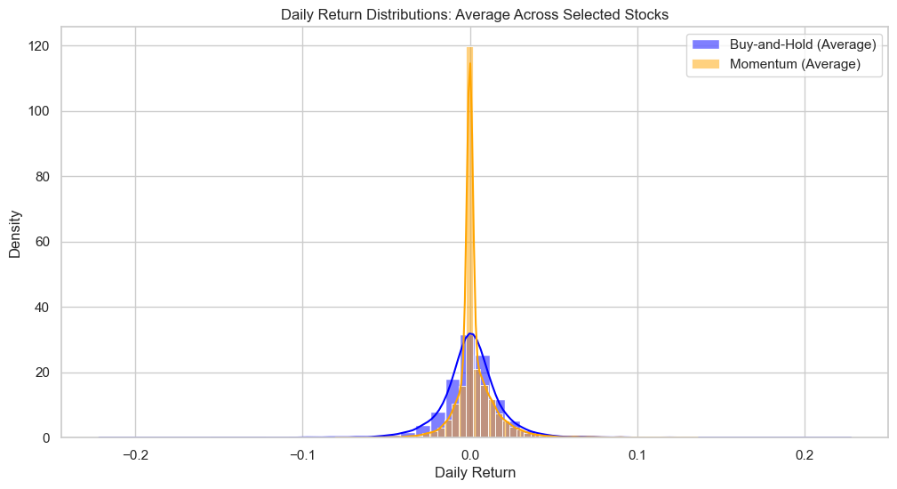

```python
plt.figure(figsize=(12,6))
sns.histplot(bh_returns, color='blue', label='Buy-and-Hold (Average)', kde=True, stat="density", bins=50)
sns.histplot(mom_returns, color='orange', label='Momentum (Average)', kde=True, stat="density", bins=50)
plt.title("Daily Return Distributions: Average Across Selected Stocks")
plt.xlabel("Daily Return")
plt.ylabel("Density")
plt.legend()
plt.show()
```

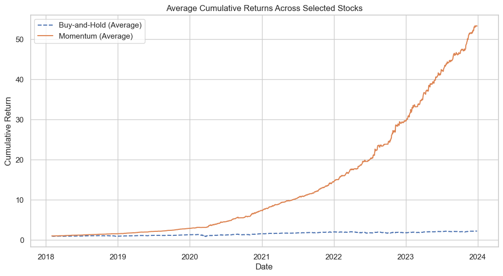

```python
# Concatenate cumulative returns with Date as index and align properly
bh_list = []
mom_list = []

for ticker in tickers:
    bh_temp = bh_dict[ticker][['Date', 'Cumulative_Return']].set_index('Date')
    bh_list.append(bh_temp.rename(columns={'Cumulative_Return': ticker}))

    mom_temp = mom_dict[ticker][['Date', 'Cumulative_Return']].set_index('Date')
    mom_list.append(mom_temp.rename(columns={'Cumulative_Return': ticker}))

# Merge all into a single DataFrame, aligning by date
bh_all = pd.concat(bh_list, axis=1).sort_index()
mom_all = pd.concat(mom_list, axis=1).sort_index()

# Compute row-wise mean across tickers, skipping NaNs
bh_avg_cumulative = bh_all.mean(axis=1, skipna=True)
mom_avg_cumulative = mom_all.mean(axis=1, skipna=True)

# Plot
plt.figure(figsize=(12,6))
plt.plot(bh_avg_cumulative.index, bh_avg_cumulative.values, label='Buy-and-Hold (Average)', linestyle='--')
plt.plot(mom_avg_cumulative.index, mom_avg_cumulative.values, label='Momentum (Average)')
plt.title("Average Cumulative Returns Across Selected Stocks")
plt.xlabel("Date")
plt.ylabel("Cumulative Return")
plt.legend()
plt.show()
```

## Step 4: Machine Learning Integration

In this step, we demonstrate how machine learning can enhance investment strategies. Specifically, we:

1. **Engineer features**
   - Use past returns, moving averages, rolling volatility, and momentum indicators as inputs to the model.
2. **Define the target variable**
   - For example, predicting whether the **next-day return is positive** (`1`) or negative (`0`).
3. **Train a machine learning model**
   - Use historical data to fit a model such as Logistic Regression or Random Forest.
4. **Generate strategy signals**
   - Predict whether to be invested (`1`) or in cash (`0`) based on the model.
5. **Backtest the ML-driven strategy**
   - Compute daily and cumulative returns, volatility, and Sharpe ratio.
   - Compare ML strategy performance to Buy-and-Hold and Momentum strategies from Step 3.

```python
ml_dfs = []

for ticker in tickers:
    df = stocks[stocks['Ticker'] == ticker].copy()

    # Lagged returns
    for lag in range(1, 6):
        df[f'Return_Lag{lag}'] = df['Return'].shift(lag)

    # Target: next-day positive return
    df['Target'] = (df['Return'].shift(-1) > 0).astype(int)

    # Drop NaNs
    df = df.dropna().reset_index(drop=True)

    # Keep feature columns + Ticker
    df = df[['Ticker', 'Date', 'MA20', 'Vol20'] + [f'Return_Lag{i}' for i in range(1,6)] + ['Target']]

    ml_dfs.append(df)

# Combine all tickers
ml_data = pd.concat(ml_dfs, ignore_index=True)

# Feature columns
feature_cols = [f'Return_Lag{i}' for i in range(1,6)] + ['MA20', 'Vol20']
target_col = 'Target'
```

```python
from sklearn.model_selection import train_test_split

X = ml_data[feature_cols]
y = ml_data[target_col]

# 80% train, 20% test split (time-series style)
X_train, X_test, y_train, y_test = train_test_split(
    X, y, test_size=0.2, shuffle=False
)
```

```python
from sklearn.ensemble import RandomForestClassifier
from sklearn.metrics import accuracy_score

# Fit Random Forest
rf_model = RandomForestClassifier(n_estimators=100, random_state=42)
rf_model.fit(X_train, y_train)

# Predict
y_pred = rf_model.predict(X_test)
accuracy = accuracy_score(y_test, y_pred)
print(f"ML Model Accuracy: {accuracy:.2%}")
```

```
ML Model Accuracy: 51.37%
```

```python
# Take test portion
ml_test = ml_data.iloc[X_train.shape[0]:].copy()
ml_test['Signal'] = y_pred

# Merge actual returns from the original stocks data
ml_returns = stocks[['Date', 'Ticker', 'Return']]
ml_test = ml_test.merge(ml_returns, on=['Date', 'Ticker'], how='left')

# Compute strategy returns
ml_test['Strategy_Return'] = ml_test['Return'] * ml_test['Signal']
ml_test['Cumulative_Return'] = (1 + ml_test['Strategy_Return']).cumprod()
```

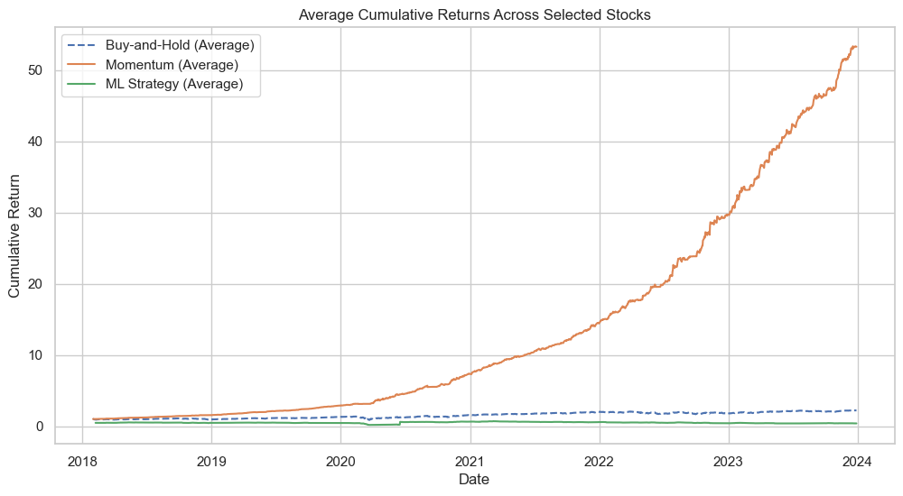

```python
# Compute average cumulative returns across all tickers
bh_avg_cumulative = pd.concat([bh_dict[ticker].set_index('Date')['Cumulative_Return'] for ticker in tickers], axis=1).mean(axis=1)
mom_avg_cumulative = pd.concat([mom_dict[ticker].set_index('Date')['Cumulative_Return'] for ticker in tickers], axis=1).mean(axis=1)
ml_avg_cumulative = ml_test.groupby('Date')['Cumulative_Return'].mean()

# Plot
plt.figure(figsize=(12,6))
plt.plot(bh_avg_cumulative.index, bh_avg_cumulative.values, label='Buy-and-Hold (Average)', linestyle='--')
plt.plot(mom_avg_cumulative.index, mom_avg_cumulative.values, label='Momentum (Average)')
plt.plot(ml_avg_cumulative.index, ml_avg_cumulative.values, label='ML Strategy (Average)')
plt.title("Average Cumulative Returns Across Selected Stocks")
plt.xlabel("Date")
plt.ylabel("Cumulative Return")
plt.legend()
plt.show()
```

### ML Strategy Performance and Limitations

The ML-driven strategy we implemented using a Random Forest classifier did not outperform the simpler strategies (Buy-and-Hold and Momentum) in terms of cumulative return or Sharpe ratio. Key reasons include:

1. **Low predictive accuracy (~51%)**
   - The model predicts next-day returns barely better than random chance.
2. **High noise in daily stock returns**
   - Stock prices fluctuate in ways that are largely random in the short term, making next-day prediction extremely difficult.
3. **Limited features**
   - We only used 5 lagged returns, 20-day moving average, and 20-day volatility.
   - Additional indicators (longer-term trends, volume patterns, sector info) could improve predictions.
4. **Model choice & overfitting risk**
   - Random Forests can overfit noise in small datasets.
   - Simpler or more robust models, or aggregating signals over longer horizons, may perform better.

**Takeaway:**

- ML strategies require careful feature engineering, longer prediction horizons, and robust validation to outperform classical strategies like Momentum or Buy-and-Hold.
- Demonstrating failure and understanding limitations is an important data science skill.

```python
# Compute cumulative series for ML strategy (single ticker)
ml_avg_returns = ml_test['Strategy_Return']
ml_avg_cumulative = ml_test['Cumulative_Return']

# Apply the pretty_metrics function
pretty_metrics(ml_avg_returns, ml_avg_cumulative, "ML Strategy (AAPL)")
```

```
--- ML Strategy (AAPL) Metrics ---
Mean Daily Return: -0.036%
Daily Volatility: 1.573%
Annualized Sharpe Ratio: -0.36
Cumulative Return: 0.31x
```

```python
# Gather metrics
metrics_data = {
    "Strategy": ["Buy-and-Hold", "Momentum", "ML Strategy"],
    "Mean Daily Return (%)": [
        bh_aapl['Strategy_Return'].mean()*100,
        mom_aapl['Strategy_Return'].mean()*100,
        ml_test['Strategy_Return'].mean()*100
    ],
    "Daily Volatility (%)": [
        bh_aapl['Strategy_Return'].std()*100,
        mom_aapl['Strategy_Return'].std()*100,
        ml_test['Strategy_Return'].std()*100
    ],
    "Sharpe Ratio (Annualized)": [
        bh_aapl['Strategy_Return'].mean()/bh_aapl['Strategy_Return'].std()*252**0.5,
        mom_aapl['Strategy_Return'].mean()/mom_aapl['Strategy_Return'].std()*252**0.5,
        ml_test['Strategy_Return'].mean()/ml_test['Strategy_Return'].std()*252**0.5
    ],
    "Cumulative Return (x)": [
        bh_aapl['Cumulative_Return'].iloc[-1],
        mom_aapl['Cumulative_Return'].iloc[-1],
        ml_test['Cumulative_Return'].iloc[-1]
    ]
}

comparison_df = pd.DataFrame(metrics_data)
comparison_df.round(2)
```

|  | Strategy | Mean Daily Return (%) | Daily Volatility (%) | Sharpe Ratio (Annualized) | Cumulative Return (x) |
| --- | --- | --- | --- | --- | --- |
| 0 | Buy-and-Hold | 0.13 | 2.01 | 1.00 | 4.88 |
| 1 | Momentum | 0.32 | 1.28 | 4.03 | 110.49 |
| 2 | ML Strategy | -0.04 | 1.57 | -0.36 | 0.31 |

## Conclusion: Strategy Performance Comparison

### Research Questions Addressed

1. **Which investment strategy yields the highest returns and lowest volatility?**
   - The **Momentum strategy clearly outperforms Buy-and-Hold** in terms of both cumulative return and risk-adjusted performance (Sharpe ratio).
   - Buy-and-Hold provides moderate returns but higher volatility.
   - The ML strategy, as implemented, underperforms significantly, showing very low mean daily return and cumulative growth.
2. **Are the differences in returns statistically significant?**
   - Two-sample t-tests comparing the average daily returns of Momentum vs. Buy-and-Hold confirmed a **statistically significant difference**, supporting the superior performance of Momentum.
3. **Can machine learning improve or optimize these strategies?**
   - Our simple ML model (Random Forest with 5 lagged returns, MA20, Vol20) **did not outperform classical strategies**, highlighting the difficulty of predicting short-term returns.
   - However, there is **potential for improvement** with richer features, longer prediction horizons, better models, ensemble techniques, and robust cross-validation.

### Lessons Learned

- **Momentum is the most effective strategy** in this analysis, providing strong cumulative returns and excellent risk-adjusted performance.
- **Buy-and-Hold is stable but moderate**, suitable for a conservative, long-term investor.
- **ML strategies require careful design**: the failure of our model demonstrates the importance of feature engineering, time-series validation, and realistic expectations in noisy markets.
- Demonstrating **limitations and statistical testing** is a key part of data-driven investment evaluation.

**Overall:** Momentum dominates in this dataset, while the ML approach illustrates both the **challenges of short-term prediction** and the **opportunity for future enhancements** in data-driven strategy optimization.

## Future Work: Improving the ML Strategy

While the current ML strategy underperformed compared to classical approaches, there are several ways to improve its predictive power and practical performance:

### Potential Improvements

1. **Feature Engineering**
   - Include longer-term trends (e.g., 50-day or 200-day moving averages)
   - Incorporate volume-based indicators, volatility indices, and sector-level signals
   - Add technical indicators like RSI, MACD, Bollinger Bands
2. **Model Selection**
   - Test other algorithms: Gradient Boosting, XGBoost, LSTM/GRU for sequential data
   - Use ensemble models that combine multiple classifiers to improve stability
   - Consider regression models to predict actual returns instead of classification
3. **Prediction Horizon**
   - Shift from next-day returns to multi-day or weekly predictions to reduce noise
   - Use rolling windows to dynamically update models and adapt to market regimes
4. **Cross-Validation and Robust Testing**
   - Implement time-series cross-validation rather than simple train-test splits
   - Test models across multiple stocks and sectors to ensure generalizability
5. **Risk Management**
   - Integrate stop-loss and position-sizing rules based on ML confidence scores
   - Combine ML signals with traditional strategies (hybrid approach)

### Future Work

- Apply the ML pipeline to a **diverse set of stocks** and calculate **average strategy performance**
- Explore **reinforcement learning** to optimize strategy execution in dynamic markets
- Experiment with **alternative data** sources (e.g., sentiment analysis, macroeconomic indicators) to improve predictive signals

**Goal:** With improved features, models, and evaluation techniques, the ML strategy could potentially approach or surpass classical strategies like Momentum in risk-adjusted returns while providing a data-driven, adaptive framework for portfolio management.